# TP3

Loic Marliot

2025-12-10

## R Markdown

```r
 library(MASS)
library(dplyr)
str(prema)
```

```
## 'data.frame':    388 obs. of  14 variables:
##  $ GEST     : int  31 28 31 27 28 33 32 30 33 28 ...
##  $ DILATE   : int  3 8 3 2 6 2 4 1 0 0 ...
##  $ EFFACE   : int  100 0 100 75 75 100 75 50 25 0 ...
##  $ CONSIS   : Factor w/ 3 levels "Mou","Moyen",..: 3 3 3 3 3 3 3 3 3 1 ...
##  $ CONTR    : Factor w/ 2 levels "Oui","Non": 1 1 2 2 2 1 1 1 1 1 ...
##  $ MEMBRAN  : Factor w/ 3 levels "Oui","Non","Incertain": 2 2 2 2 2 1 2 2 2 2 ...
##  $ AGE      : int  26 25 28 27 17 25 25 29 22 25 ...
##  $ STRAT    : Factor w/ 4 levels "1","2","3","4": 3 3 3 2 3 4 4 3 4 3 ...
##  $ GRAVID   : int  1 1 2 2 1 2 2 2 1 3 ...
##  $ PARIT    : int  0 0 0 1 0 0 1 1 0 1 ...
##  $ DIAB     : Factor w/ 2 levels "Oui","Non": 2 2 2 2 2 2 2 2 2 2 ...
##  $ TRANSF   : Factor w/ 2 levels "Oui","Non": 2 1 1 1 1 1 1 1 2 2 ...
##  $ GEMEL    : Factor w/ 2 levels "Simple","Multiple": 1 2 1 2 1 1 1 1 2 1 ...
##  $ PREMATURE: Factor w/ 2 levels "negatif","positif": 2 2 2 2 2 2 2 2 1 2 ...
```

## Including Plots

```r
prema$GEMEL = as.factor(prema$GEMEL)
prema$PREMATURE = as.factor(prema$PREMATURE)
attach(prema)
contingence=table(prema$PREMATURE,prema$GEMEL)
```

8.75

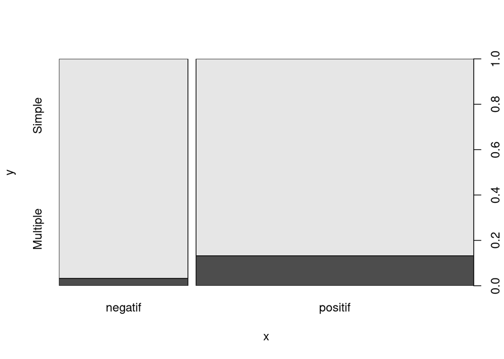

```r
plot(prema$PREMATURE,prema$GEMEL)
```

```r
model1 <- glm(PREMATURE ~ GEMEL, family = "binomial", data = prema)
summary(model1)
```

```
##
## Call:
## glm(formula = PREMATURE ~ GEMEL, family = "binomial", data = prema)
##
## Coefficients:
##               Estimate Std. Error z value Pr(>|z|)
## (Intercept)     0.6590     0.1129   5.836 5.36e-09 ***
## GEMELMultiple   1.5101     0.5397   2.798  0.00514 **
## ---
## Signif. codes:  0 '***' 0.001 '**' 0.01 '*' 0.05 '.' 0.1 ' ' 1
##
## (Dispersion parameter for binomial family taken to be 1)
##
##     Null deviance: 484.69  on 387  degrees of freedom
## Residual deviance: 473.69  on 386  degrees of freedom
## AIC: 477.69
##
## Number of Fisher Scoring iterations: 4
```

```r
oddRatio = contingence[1,1] * contingence[2,2]/(contingence[1,2] * contingence[2,1])
oddRatiobis = exp(1.5101)
```

1 paramètre :

```r
logLik(model1)
```

```
## 'log Lik.' -236.8427 (df=2)
```

```r
AIC = -2 * logLik(model1) +4
```

```r
by(prema$EFFACE,INDICES=prema$PREMATURE,FUN=mean)
```

```
## prema$PREMATURE: negatif
## [1] 27.02439
## ------------------------------------------------------------
## prema$PREMATURE: positif
## [1] 51.80377
```

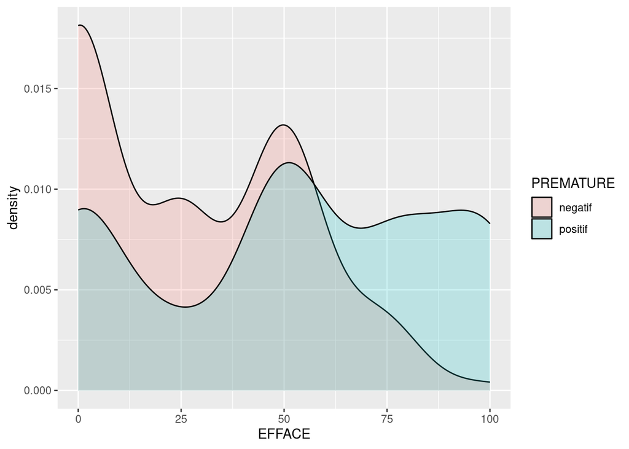

```r
library("ggplot2")
ggplot(prema, aes(EFFACE, fill = PREMATURE)) + geom_density(alpha = 0.2)
```

#10

```r
model2 <- glm(PREMATURE ~ EFFACE, family = "binomial", data = prema)
summary(model2)
```

```
##
## Call:
## glm(formula = PREMATURE ~ EFFACE, family = "binomial", data = prema)
##
## Coefficients:
##              Estimate Std. Error z value Pr(>|z|)
## (Intercept) -0.121256   0.170024  -0.713    0.476
## EFFACE       0.022799   0.003634   6.273 3.53e-10 ***
## ---
## Signif. codes:  0 '***' 0.001 '**' 0.01 '*' 0.05 '.' 0.1 ' ' 1
##
## (Dispersion parameter for binomial family taken to be 1)
##
##     Null deviance: 484.69  on 387  degrees of freedom
## Residual deviance: 439.51  on 386  degrees of freedom
## AIC: 443.51
##
## Number of Fisher Scoring iterations: 3
```

L’effacement du col est très significatif, il favorise un accouchement précoce. #11

```r
pi<-function(x){
  return (exp(-0.12 + 0.022*x)/(1+exp(-0.12 + 0.022*x)))
}
```

#12

```r
pi(60)
```

```
## [1] 0.7685248
```

La proba d’accoucher prématurément lors d’un effacement du col est de 0.7685248

#13

```r
pi(prema$EFFACE)
```

```
##   [1] 0.8889440 0.4700359 0.8889440 0.8220063 0.8220063 0.8889440 0.8220063
##   [8] 0.7271082 0.6058737 0.4700359 0.8889440 0.8889440 0.7271082 0.7271082
##  [15] 0.6058737 0.7271082 0.4700359 0.8889440 0.4700359 0.4700359 0.4700359
##  [22] 0.7271082 0.8889440 0.6813537 0.6318124 0.8053384 0.5793243 0.8053384
##  [29] 0.7271082 0.7271082 0.7271082 0.8375349 0.8053384 0.8375349 0.4700359
##  [36] 0.4700359 0.4700359 0.4700359 0.4700359 0.7271082 0.5793243 0.7271082
##  [43] 0.6058737 0.7271082 0.4700359 0.4700359 0.8776111 0.7271082 0.6318124
##  [50] 0.8220063 0.5793243 0.7271082 0.7271082 0.4700359 0.8053384 0.7271082
##  [57] 0.8652969 0.7271082 0.7271082 0.7271082 0.7271082 0.7271082 0.4700359
##  [64] 0.7271082 0.4700359 0.7271082 0.8220063 0.4700359 0.7271082 0.7271082
##  [71] 0.6058737 0.7685248 0.5249792 0.4700359 0.8889440 0.4700359 0.7271082
##  [78] 0.8889440 0.4700359 0.6058737 0.4700359 0.8889440 0.7271082 0.6058737
##  [85] 0.4700359 0.4700359 0.8220063 0.7271082 0.4700359 0.6058737 0.4700359
##  [92] 0.8867535 0.4700359 0.7271082 0.7271082 0.8867535 0.7685248 0.7271082
##  [99] 0.7271082 0.8867535 0.8652969 0.5249792 0.8375349 0.7271082 0.8375349
```

[output cut: 41 more lines]

```r
pi_hat = predict(model2, prema, type = "response")
model2$fitted.values
```

```
##         1         2         3         4         5         6         7         8
## 0.8964726 0.4697230 0.8964726 0.8304275 0.8304275 0.8964726 0.8304275 0.7347169
##         9        10        11        12        13        14        15        16
## 0.6103339 0.4697230 0.8964726 0.8964726 0.7347169 0.7347169 0.6103339 0.7347169
##        17        18        19        20        21        22        23        24
## 0.4697230 0.8964726 0.4697230 0.4697230 0.4697230 0.7347169 0.8964726 0.6879814
##        25        26        27        28        29        30        31        32
## 0.6370794 0.8137655 0.5829077 0.8137655 0.7347169 0.7347169 0.7347169 0.8458811
##        33        34        35        36        37        38        39        40
## 0.8137655 0.8458811 0.4697230 0.4697230 0.4697230 0.4697230 0.4697230 0.7347169
##        41        42        43        44        45        46        47        48
## 0.5829077 0.7347169 0.6103339 0.7347169 0.4697230 0.4697230 0.8854046 0.7347169
##        49        50        51        52        53        54        55        56
## 0.6370794 0.8304275 0.5829077 0.7347169 0.7347169 0.4697230 0.8137655 0.7347169
##        57        58        59        60        61        62        63        64
## 0.8733206 0.7347169 0.7347169 0.7347169 0.7347169 0.7347169 0.4697230 0.7347169
##        65        66        67        68        69        70        71        72
## 0.4697230 0.7347169 0.8304275 0.4697230 0.7347169 0.7347169 0.6103339 0.7767240
##        73        74        75        76        78        80        81        82
## 0.5266578 0.4697230 0.8964726 0.4697230 0.7347169 0.8964726 0.4697230 0.6103339
##        83        84        85        86        87        88        89        90
## 0.4697230 0.8964726 0.7347169 0.6103339 0.4697230 0.4697230 0.8304275 0.7347169
##        91        92        93        94        95        96        97        98
## 0.4697230 0.6103339 0.4697230 0.8943375 0.4697230 0.7347169 0.7347169 0.8943375
##        99       100       101       102       103       104       105       106
## 0.7767240 0.7347169 0.7347169 0.8943375 0.8733206 0.5266578 0.8458811 0.7347169
##       107       108       109       110       111       112       113       114
## 0.8458811 0.7347169 0.7347169 0.7767240 0.7347169 0.7347169 0.7767240 0.4697230
##       115       116       117       118       119       120       121       122
## 0.8964726 0.7347169 0.6370794 0.8964726 0.8304275 0.8964726 0.7347169 0.4697230
##       123       124       125       126       127       128       129       130
## 0.8964726 0.8964726 0.8964726 0.7347169 0.8304275 0.5266578 0.8964726 0.4697230
##       131       132       133       134       135       136       137       138
## 0.4697230 0.8964726 0.4697230 0.8304275 0.7347169 0.8458811 0.8964726 0.8964726
##       139       140       141       142       143       144       145       146
## 0.7347169 0.8964726 0.8458811 0.8964726 0.7347169 0.7767240 0.8964726 0.7347169
##       147       148       149       150       151       152       153       154
## 0.4697230 0.5829077 0.6103339 0.4697230 0.4697230 0.8964726 0.7347169 0.6103339
##       155       156       157       158       159       160       161       162
## 0.8304275 0.8304275 0.7347169 0.5266578 0.8304275 0.8964726 0.4697230 0.6103339
```

[output cut: 43 more lines]

```
## 0.6103339 0.4697230 0.4697230 0.4697230 0.6103339 0.7347169 0.4697230 0.4697230
##       339       340       341       342       343       344       345       346
## 0.6370794 0.7347169 0.4697230 0.4697230 0.8458811 0.8304275 0.8458811 0.7347169
##       347       348       349       350       351       352       353       354
## 0.4697230 0.8304275 0.8304275 0.7347169 0.8304275 0.7347169 0.8733206 0.8304275
##       355       356       357       358       359       360       361       362
## 0.4697230 0.4697230 0.4697230 0.4697230 0.4697230 0.8964726 0.7347169 0.8964726
##       363       364       365       366       367       368       369       370
## 0.8601635 0.4697230 0.7347169 0.8304275 0.4697230 0.7347169 0.8304275 0.8304275
##       371       372       373       374       375       376       377       378
## 0.8964726 0.4697230 0.4697230 0.4697230 0.8733206 0.8304275 0.7347169 0.7347169
##       379       380       381       382       383       384       385       386
## 0.7347169 0.5266578 0.7347169 0.5829077 0.7347169 0.8964726 0.6103339 0.8304275
##       387       388       389       390
## 0.4697230 0.8964726 0.4697230 0.8964726
```

Les valeurs diffèrent mais de peu. L’ordre des valeurs restent similaires.

#Q14

```r
model3 <- glm(PREMATURE ~ GEMEL + EFFACE, family = "binomial",
data = prema)
summary(model3)
```

```
##
## Call:
## glm(formula = PREMATURE ~ GEMEL + EFFACE, family = "binomial",
##     data = prema)
##
## Coefficients:
##                Estimate Std. Error z value Pr(>|z|)
## (Intercept)   -0.192235   0.173163  -1.110   0.2669
## GEMELMultiple  1.343230   0.553097   2.429   0.0152 *
## EFFACE         0.022130   0.003648   6.066 1.31e-09 ***
## ---
## Signif. codes:  0 '***' 0.001 '**' 0.01 '*' 0.05 '.' 0.1 ' ' 1
##
## (Dispersion parameter for binomial family taken to be 1)
##
##     Null deviance: 484.69  on 387  degrees of freedom
## Residual deviance: 431.80  on 385  degrees of freedom
## AIC: 437.8
##
## Number of Fisher Scoring iterations: 4
```

L’effacement est très significatif alors que la naissance de plusieurs bébés est moins significatif. Faire un accouchement prématuré sera favorisé par l’effacement du col principalement, bien que la naissance de jumeaux aura lui-même un impact, mais de plus faible importance.

#Q15

```r
anova(model2, model3, test = "LRT")
```

```
## Analysis of Deviance Table
##
## Model 1: PREMATURE ~ EFFACE
## Model 2: PREMATURE ~ GEMEL + EFFACE
##   Resid. Df Resid. Dev Df Deviance Pr(>Chi)
## 1       386     439.51
## 2       385     431.80  1   7.7192 0.005464 **
## ---
## Signif. codes:  0 '***' 0.001 '**' 0.01 '*' 0.05 '.' 0.1 ' ' 1
```

#Q16

La p-valeur est de 0.005464, on rejette l’hypothèse nulle, selon laquelle il y aurait des variables qui ne seraient pas inclus dans le petit modèle qui seraient nulles . Nous garderons donc le modèle 3 car il a des variables non-nulles qui ne sont pas incluses dans le petit modèle qui ne sont pas nulles.

#Q17

```r
fullmodel <- glm(PREMATURE ~ ., family = "binomial", data = prema)
summary(fullmodel)
```

```
##
## Call:
## glm(formula = PREMATURE ~ ., family = "binomial", data = prema)
##
## Coefficients:
##                   Estimate Std. Error z value Pr(>|z|)
## (Intercept)       4.179413   3.154945   1.325  0.18526
## GEST              0.031486   0.126861   0.248  0.80399
## DILATE            0.465620   0.160258   2.905  0.00367 **
## EFFACE            0.016293   0.004993   3.263  0.00110 **
## CONSISMoyen      -0.003735   0.413391  -0.009  0.99279
## CONSISFerme       0.109046   0.422942   0.258  0.79654
## CONTRNon         -0.271793   0.571600  -0.475  0.63443
## MEMBRANNon       -2.502556   0.504874  -4.957 7.17e-07 ***
## MEMBRANIncertain -1.743328   0.873314  -1.996  0.04591 *
## AGE              -0.024745   0.026793  -0.924  0.35571
## STRAT2           -0.513793   1.009553  -0.509  0.61080
## STRAT3           -1.027735   1.282474  -0.801  0.42292
## STRAT4           -1.651263   1.638381  -1.008  0.31352
## GRAVID            0.261498   0.147723   1.770  0.07670 .
## PARIT            -0.693088   0.206282  -3.360  0.00078 ***
## DIABNon          -1.381361   0.939525  -1.470  0.14149
## TRANSFNon        -0.500855   0.293511  -1.706  0.08793 .
## GEMELMultiple     1.182608   0.621102   1.904  0.05690 .
## ---
## Signif. codes:  0 '***' 0.001 '**' 0.01 '*' 0.05 '.' 0.1 ' ' 1
##
## (Dispersion parameter for binomial family taken to be 1)
##
##     Null deviance: 480.86  on 384  degrees of freedom
## Residual deviance: 349.28  on 367  degrees of freedom
##   (3 observations effacées parce que manquantes)
## AIC: 385.28
##
## Number of Fisher Scoring iterations: 6
```

```r
step(object = fullmodel)
```

```
## Start:  AIC=385.28
## PREMATURE ~ GEST + DILATE + EFFACE + CONSIS + CONTR + MEMBRAN +
##     AGE + STRAT + GRAVID + PARIT + DIAB + TRANSF + GEMEL
##
##           Df Deviance    AIC
## - STRAT    3   350.78 380.78
## - CONSIS   2   349.43 381.43
## - GEST     1   349.35 383.35
## - CONTR    1   349.51 383.51
## - AGE      1   350.14 384.14
## <none>         349.28 385.28
## - DIAB     1   351.72 385.72
## - TRANSF   1   352.21 386.21
## - GRAVID   1   352.69 386.69
## - GEMEL    1   353.45 387.45
## - DILATE   1   358.69 392.69
## - EFFACE   1   360.45 394.45
## - PARIT    1   361.52 395.52
## - MEMBRAN  2   386.22 418.22
##
## Step:  AIC=380.78
## PREMATURE ~ GEST + DILATE + EFFACE + CONSIS + CONTR + MEMBRAN +
##     AGE + GRAVID + PARIT + DIAB + TRANSF + GEMEL
##
##           Df Deviance    AIC
## - CONSIS   2   350.98 376.98
## - CONTR    1   350.98 378.98
## - AGE      1   351.61 379.61
## <none>         350.78 380.78
## - DIAB     1   353.50 381.50
## - TRANSF   1   353.61 381.61
## - GRAVID   1   354.10 382.10
## - GEMEL    1   354.68 382.68
## - GEST     1   356.58 384.58
## - DILATE   1   360.87 388.87
## - EFFACE   1   361.52 389.52
## - PARIT    1   363.32 391.32
## - MEMBRAN  2   387.55 413.55
##
## Step:  AIC=376.98
```

[output cut: 34 more lines]

```
## Step:  AIC=374.04
## PREMATURE ~ GEST + DILATE + EFFACE + MEMBRAN + GRAVID + PARIT +
##     DIAB + TRANSF + GEMEL
##
##           Df Deviance    AIC
## <none>         352.04 374.04
## - DIAB     1   354.68 374.68
## - GRAVID   1   354.88 374.88
## - TRANSF   1   355.69 375.69
## - GEMEL    1   356.00 376.00
## - GEST     1   357.99 377.99
## - DILATE   1   362.95 382.95
## - EFFACE   1   364.42 384.42
## - PARIT    1   365.58 385.58
## - MEMBRAN  2   388.21 406.21
```

```
##
## Call:  glm(formula = PREMATURE ~ GEST + DILATE + EFFACE + MEMBRAN +
##     GRAVID + PARIT + DIAB + TRANSF + GEMEL, family = "binomial",
##     data = prema)
##
## Coefficients:
##      (Intercept)              GEST            DILATE            EFFACE
##          6.55339          -0.10552           0.49203           0.01621
##       MEMBRANNon  MEMBRANIncertain            GRAVID             PARIT
##         -2.39882          -1.61375           0.23283          -0.71358
##          DIABNon         TRANSFNon     GEMELMultiple
##         -1.42410          -0.53541           1.13898
##
## Degrees of Freedom: 384 Total (i.e. Null);  374 Residual
##   (3 observations effacées parce que manquantes)
## Null Deviance:       480.9
## Residual Deviance: 352   AIC: 374
```

Avec la fonction step, nous devrions choisir GEST + DILATE + EFFACE + MEMBRAN + GRAVID + PARIT + DIAB + TRANSF + GEMEL

```r
anova(glm(formula = PREMATURE ~ GEST + DILATE + EFFACE + MEMBRAN +
    GRAVID + PARIT + DIAB + TRANSF + GEMEL, family = "binomial",
    data = prema), fullmodel, test = "LRT")
```

```
## Analysis of Deviance Table
##
## Model 1: PREMATURE ~ GEST + DILATE + EFFACE + MEMBRAN + GRAVID + PARIT +
##     DIAB + TRANSF + GEMEL
## Model 2: PREMATURE ~ GEST + DILATE + EFFACE + CONSIS + CONTR + MEMBRAN +
##     AGE + STRAT + GRAVID + PARIT + DIAB + TRANSF + GEMEL
##   Resid. Df Resid. Dev Df Deviance Pr(>Chi)
## 1       374     352.04
## 2       367     349.28  7   2.7594   0.9063
```

Le modèle recuded devrait être gardé car nous avons rejeté l’hypothèse alternative, nous garderons le plus petit modèle.

```r
reduced <- glm(formula = PREMATURE ~ GEST + DILATE + EFFACE + MEMBRAN +
    GRAVID + PARIT + DIAB + TRANSF + GEMEL, family = "binomial",
    data = prema)
```

```r
exp(cbind(OR=coef(reduced), confint(reduced)))
```

```
##                            OR       2.5 %       97.5 %
## (Intercept)      701.61700002 24.75278879 2.577511e+04
## GEST               0.89985930  0.82345028 9.797992e-01
## DILATE             1.63563388  1.21306873 2.251895e+00
## EFFACE             1.01633713  1.00712218 1.026003e+00
## MEMBRANNon         0.09082473  0.03135032 2.202332e-01
## MEMBRANIncertain   0.19913895  0.03851807 1.169389e+00
## GRAVID             1.26216300  0.96404506 1.692509e+00
## PARIT              0.48988898  0.32474761 7.215547e-01
## DIABNon            0.24072586  0.03012571 1.324061e+00
## TRANSFNon          0.58542751  0.33637329 1.013921e+00
## GEMELMultiple      3.12356957  1.01618286 1.191616e+01
```

GEST,MEMBRANNon,PARIT,DIABNon,TRANSFNon sont des facteurs protecteur, car OR < 1 pour un accouchement prématuré. DILATE,GRAVID,GEMELMultiple sont des facteurs de risques pour un accouchement prématuré.

EFFACE, n’a que peu d’influence étonnamment

#20

```r
(reduced$fitted.values)
```

```
##          1          2          3          4          5          6          7
## 0.90494866 0.99384332 0.95354492 0.95129350 0.98487831 0.99114133 0.90800454
##          8          9         10         11         12         13         14
## 0.65006497 0.62008974 0.31550358 0.97707579 0.92942172 0.98748408 0.73911856
##         15         16         17         18         19         20         21
## 0.35883611 0.78406573 0.44961867 0.94207162 0.37641389 0.52250129 0.23208402
##         22         23         24         25         26         27         28
## 0.77419845 0.99347376 0.48309973 0.98699302 0.57229390 0.48403103 0.75022215
##         29         30         31         32         33         34         35
## 0.69237562 0.88029762 0.66154309 0.94987004 0.57761970 0.97856060 0.32022887
##         36         37         38         40         41         42         43
## 0.86761819 0.58002911 0.42642613 0.49177929 0.49324824 0.95785843 0.26419455
##         44         45         46         47         48         49         50
## 0.42492161 0.23872327 0.35772022 0.98038359 0.04640198 0.22295571 0.95394159
##         51         52         53         54         55         56         57
## 0.35131246 0.37434170 0.37698751 0.05357260 0.60061161 0.54342263 0.68800275
##         58         59         60         61         62         63         64
## 0.46450542 0.84522386 0.60132161 0.90876279 0.43932067 0.42642613 0.48903163
##         65         66         67         68         69         70         71
## 0.24077943 0.43932067 0.51955329 0.19084892 0.96656620 0.62062895 0.40531912
##         72         73         74         75         76         78         80
## 0.52500536 0.38460287 0.30325183 0.95800159 0.59171574 0.85655091 0.93171864
##         81         82         83         84         85         86         87
## 0.85038905 0.71448373 0.83345937 0.99383192 0.99359879 0.91697870 0.44961867
##         88         89         90         91         92         93         94
## 0.61127691 0.97832728 0.93712087 0.37037474 0.98343000 0.38416016 0.99853458
##         95         96         97         98         99        100        101
## 0.68012872 0.54721609 0.98185286 0.96693974 0.99908626 0.99481721 0.84504913
##        102        103        104        105        106        107        108
## 0.76754723 0.87999540 0.76604826 0.98631032 0.90847614 0.96419714 0.75433497
##        109        110        111        112        113        114        115
## 0.77151263 0.88443875 0.57044447 0.62833693 0.71139984 0.61712021 0.99499290
##        116        117        118        119        120        121        122
## 0.76086387 0.71233148 0.95557605 0.92248840 0.93443993 0.98723553 0.55757860
##        123        124        125        126        127        128        129
## 0.99450812 0.99772031 0.94268419 0.65262679 0.96823795 0.71007135 0.99114133
##        130        131        132        133        134        135        136
## 0.81829357 0.31736316 0.97333704 0.72965700 0.74708674 0.99398210 0.99378546
##        137        138        139        140        141        142        143
## 0.99315021 0.99673261 0.89886967 0.77180768 0.97775956 0.98527881 0.97075457
```

[output cut: 55 more lines]

```
## 0.35456483 0.99138190 0.56983670 0.23872327 0.33770494 0.31528566 0.47389295
##        342        343        344        345        346        347        348
## 0.32831162 0.97707708 0.99053530 0.88022204 0.79000457 0.73576642 0.85924097
##        349        350        351        352        353        354        355
## 0.95009996 0.80995211 0.97337078 0.67597907 0.97814767 0.70259567 0.33560073
##        356        357        358        359        360        361        362
## 0.26059194 0.35952088 0.51773170 0.46209176 0.94329066 0.87632221 0.99008866
##        363        364        365        366        367        368        369
## 0.94595346 0.29317151 0.39086626 0.79006924 0.42642613 0.86155482 0.99262349
##        370        371        372        373        374        375        376
## 0.94707042 0.98331682 0.92552242 0.44768217 0.34047730 0.99063091 0.62145702
##        377        378        379        380        381        382        383
## 0.52358854 0.67844501 0.96016455 0.44030771 0.41351910 0.88713031 0.56171147
##        384        385        386        387        388        389        390
## 0.76981480 0.47248230 0.97081611 0.83345937 0.96880543 0.66560567 0.68754151
```

La variance sempble très élevée, ce qui montre que la prédiction n’est pas idéale.

#Q21

```r
data<-prema
```

```r
data<-data %>% mutate(valeur_aposteriori = ifelse(data$PREMATURE=="positif",1,0))
```

```r
na.omit(data)
```

```
##     GEST DILATE EFFACE CONSIS CONTR   MEMBRAN AGE STRAT GRAVID PARIT DIAB
## 1     31      3    100  Ferme   Oui       Non  26     3      1     0  Non
## 2     28      8      0  Ferme   Oui       Non  25     3      1     0  Non
## 3     31      3    100  Ferme   Non       Non  28     3      2     0  Non
## 4     27      2     75  Ferme   Non       Non  27     2      2     1  Non
## 5     28      6     75  Ferme   Non       Non  17     3      1     0  Non
## 6     33      2    100  Ferme   Oui       Oui  25     4      2     0  Non
## 7     32      4     75  Ferme   Oui       Non  25     4      2     1  Non
## 8     30      1     50  Ferme   Oui       Non  29     3      2     1  Non
## 9     33      0     25  Ferme   Oui       Non  22     4      1     0  Non
## 10    28      0      0    Mou   Oui       Non  25     3      3     1  Non
## 11    28      2    100  Ferme   Oui       Non  29     3      1     0  Non
## 12    33      3    100  Ferme   Oui       Non  21     4      1     0  Non
## 13    28      1     50  Ferme   Oui       Oui  29     3      2     1  Non
## 14    26      1     50  Ferme   Oui       Non  19     2      2     1  Non
```

[output cut: 757 more lines]

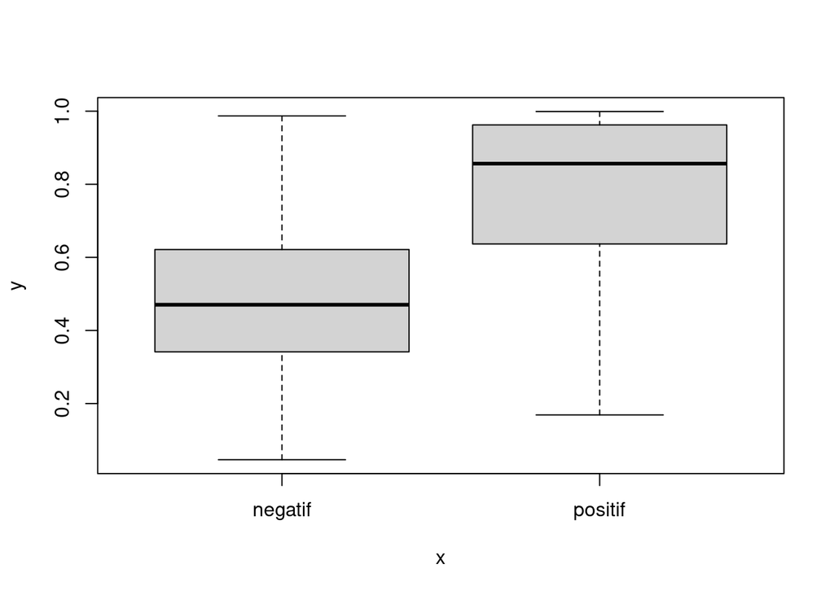

```r
dataSup=na.omit(data)
plot(x=dataSup$PREMATURE,y=reduced$fitted.values)
```

Le modèle est bon car les boxplot ne se chevauche pas

```r
dataSup=na.omit(data)
data<-dataSup %>% mutate(valeur_apriori = ifelse(reduced$fitted.values>0.5,1,0))
```

```r
s=reduced$fitted.values
S2=s>0.5
table(na.omit(prema)$PREMATURE,S2)
```

```
##          S2
##           FALSE TRUE
##   negatif    66   56
##   positif    43  220
```

#Q22

```r
seuil=0.5

S3=c()
for (i in 1:385){
  if(s[i]>seuil){
    S3[i]=TRUE
    seuil=s[i]
  }
  else{
    S3[i]=FALSE
  }
}
```

```r
table(na.omit(prema)$PREMATURE,S3)
```

```
##          S3
##           FALSE TRUE
##   negatif   122    0
##   positif   259    4
```

#Q23

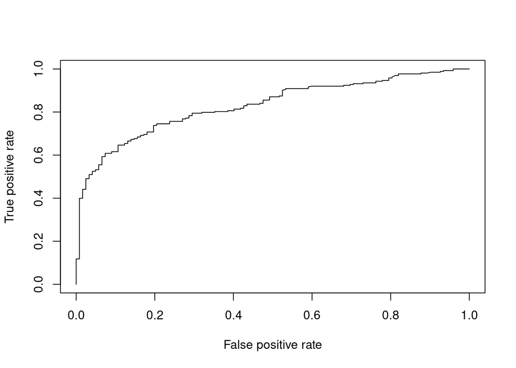

```r
library(ROCR)
pred = prediction(s, na.omit(prema)$PREMATURE)
perf = performance(pred, "tpr", "fpr")
plot(perf)
```

#Q24

```r
perf@x.values[[1]]
```

```
##   [1] 0.000000000 0.000000000 0.000000000 0.000000000 0.000000000 0.000000000
##   [7] 0.000000000 0.000000000 0.000000000 0.000000000 0.000000000 0.000000000
##  [13] 0.000000000 0.000000000 0.000000000 0.000000000 0.000000000 0.000000000
##  [19] 0.000000000 0.000000000 0.000000000 0.000000000 0.000000000 0.000000000
##  [25] 0.000000000 0.000000000 0.000000000 0.000000000 0.000000000 0.000000000
##  [31] 0.000000000 0.008196721 0.008196721 0.008196721 0.008196721 0.008196721
##  [37] 0.008196721 0.008196721 0.008196721 0.008196721 0.008196721 0.008196721
##  [43] 0.008196721 0.008196721 0.008196721 0.008196721 0.008196721 0.008196721
##  [49] 0.008196721 0.008196721 0.008196721 0.008196721 0.008196721 0.008196721
##  [55] 0.008196721 0.008196721 0.008196721 0.008196721 0.008196721 0.008196721
##  [61] 0.008196721 0.008196721 0.008196721 0.008196721 0.008196721 0.008196721
##  [67] 0.008196721 0.008196721 0.008196721 0.008196721 0.008196721 0.008196721
##  [73] 0.008196721 0.008196721 0.008196721 0.008196721 0.008196721 0.008196721
##  [79] 0.008196721 0.008196721 0.008196721 0.008196721 0.008196721 0.008196721
##  [85] 0.008196721 0.008196721 0.008196721 0.008196721 0.008196721 0.008196721
```

[output cut: 47 more lines]

```r
perf@y.values[[1]]
```

```
##   [1] 0.000000000 0.003802281 0.007604563 0.011406844 0.015209125 0.019011407
##   [7] 0.022813688 0.026615970 0.030418251 0.034220532 0.038022814 0.041825095
##  [13] 0.045627376 0.049429658 0.053231939 0.057034221 0.060836502 0.064638783
##  [19] 0.068441065 0.072243346 0.076045627 0.083650190 0.087452471 0.091254753
##  [25] 0.095057034 0.098859316 0.102661597 0.106463878 0.110266160 0.114068441
##  [31] 0.117870722 0.117870722 0.121673004 0.125475285 0.129277567 0.133079848
##  [37] 0.136882129 0.140684411 0.144486692 0.148288973 0.152091255 0.155893536
##  [43] 0.159695817 0.163498099 0.167300380 0.171102662 0.174904943 0.178707224
##  [49] 0.182509506 0.186311787 0.190114068 0.193916350 0.197718631 0.201520913
##  [55] 0.205323194 0.209125475 0.212927757 0.216730038 0.220532319 0.224334601
##  [61] 0.228136882 0.231939163 0.235741445 0.239543726 0.243346008 0.247148289
##  [67] 0.250950570 0.254752852 0.258555133 0.262357414 0.266159696 0.269961977
##  [73] 0.273764259 0.281368821 0.285171103 0.288973384 0.292775665 0.296577947
##  [79] 0.304182510 0.307984791 0.311787072 0.315589354 0.319391635 0.323193916
##  [85] 0.326996198 0.330798479 0.334600760 0.338403042 0.342205323 0.346007605
```

[output cut: 47 more lines]

```r
perf@alpha.values[[1]]
```

```
##   [1]        Inf 0.99908626 0.99893525 0.99853458 0.99772031 0.99673261
##   [7] 0.99636718 0.99499290 0.99481721 0.99450812 0.99398210 0.99384332
##  [13] 0.99383192 0.99378546 0.99359879 0.99347376 0.99315021 0.99275469
##  [19] 0.99262349 0.99239373 0.99138190 0.99114133 0.99063091 0.99053530
##  [25] 0.99008866 0.98871517 0.98785793 0.98760079 0.98748408 0.98723553
##  [31] 0.98714924 0.98699302 0.98631032 0.98527881 0.98487831 0.98464033
##  [37] 0.98343000 0.98331682 0.98283100 0.98185286 0.98038359 0.98018550
##  [43] 0.97856060 0.97832728 0.97814767 0.97808679 0.97775956 0.97707708
##  [49] 0.97707579 0.97456471 0.97450644 0.97337078 0.97333704 0.97185217
##  [55] 0.97081611 0.97075457 0.96880543 0.96842411 0.96823795 0.96727746
##  [61] 0.96693974 0.96656620 0.96615958 0.96545388 0.96419714 0.96415974
##  [67] 0.96247432 0.96226159 0.96198628 0.96016455 0.95800159 0.95785843
##  [73] 0.95557605 0.95406253 0.95394159 0.95354492 0.95204063 0.95129350
##  [79] 0.95009996 0.94987004 0.94707042 0.94595346 0.94543794 0.94493848
##  [85] 0.94329066 0.94268419 0.94207162 0.94006493 0.93951762 0.93767743
```

[output cut: 47 more lines]

#q25

```r
AUC = performance(pred, "auc")
attr(AUC, "y.values")[[1]]
```

```
## [1] 0.8300037
```

#Q26